# MPDW

# Masukkan Data

## LIBRARY

```r
library(forecast)
```

```r
library(graphics)
library(TTR)
library(rio)
```

## IMPOR DATA

```r
data1 <- import("C:\\Users\\Lenovo\\Downloads\\ispu_anggota_5.csv")
data1$periode <- 1:nrow(data1)
head(data1)
```

```
##      tanggal            stasiun pm25 pm10 so2 co o3 no2 max critical categori
## 1 2021-11-30 DKI1 (Bunderan HI)   50   29  31  9 18   7  50     PM25     BAIK
## 2 2021-12-01 DKI1 (Bunderan HI)   65   49  33 13 15  12  65     PM25   SEDANG
## 3 2021-12-02 DKI1 (Bunderan HI)   34   28  31  7 15   5  34     PM25     BAIK
## 4 2021-12-03 DKI1 (Bunderan HI)   31   49   9 19  7  49  49     PM25     BAIK
## 5 2021-12-04 DKI1 (Bunderan HI)   52   39  35 13 15   9  52     PM25   SEDANG
## 6 2021-12-05 DKI1 (Bunderan HI)   57   41  39 15 15   9  57     PM25   SEDANG
##   periode
## 1       1
## 2       2
## 3       3
## 4       4
## 5       5
## 6       6
```

```r
str(data1)
```

```
## 'data.frame':    112 obs. of  12 variables:
##  $ tanggal : IDate, format: "2021-11-30" "2021-12-01" ...
##  $ stasiun : chr  "DKI1 (Bunderan HI)" "DKI1 (Bunderan HI)" "DKI1 (Bunderan HI)" "DKI1 (Bunderan HI)" ...
##  $ pm25    : num  50 65 34 31 52 57 81 31 60 50 ...
##  $ pm10    : num  29 49 28 49 39 41 60 30 45 33 ...
##  $ so2     : num  31 33 31 9 35 39 55 34 33 36 ...
##  $ co      : num  9 13 7 19 13 15 23 12 17 10 ...
##  $ o3      : num  18 15 15 7 15 15 18 16 18 21 ...
##  $ no2     : num  7 12 5 49 9 9 11 9 10 11 ...
##  $ max     : num  50 65 34 49 52 57 81 34 60 50 ...
##  $ critical: chr  "PM25" "PM25" "PM25" "PM25" ...
##  $ categori: chr  "BAIK" "SEDANG" "BAIK" "BAIK" ...
##  $ periode : int  1 2 3 4 5 6 7 8 9 10 ...
```

```r
dim(data1)
```

```
## [1] 112  12
```

## Ubah menjadi objek deret waktu

```r
data1.ts <- ts(data1$pm10)
data1.ts
```

```
## Time Series:
## Start = 1
## End = 112
## Frequency = 1
##   [1] 29 49 28 49 39 41 60 30 45 33 46 28 44 31 46 58 56 53 51 58 52 52 63 56 34
##  [26] 53 35 52 51 31 55 62 44 32 31 30 38 31 25 28 25 37 42 53 57 51 46 34 40 55
##  [51] 53 42 42 37 21 29 30 41 47 33 50 37 50 46 49 28 55 45 34 41 30 31 25 34 20
##  [76] 28 23 21 29 33 54 56 38 24 29 36 28 36 34 32 43 38 29 38 31 33 31 37 42 47
## [101] 45 44 61 53 51 29 64 49 44 53 54 54
```

# Analisis Data

## EKSPLORASI DATA

```r
summary(data1.ts)
```

```
##    Min. 1st Qu.  Median    Mean 3rd Qu.    Max.
##   20.00   31.00   41.00   40.98   51.00   64.00
```

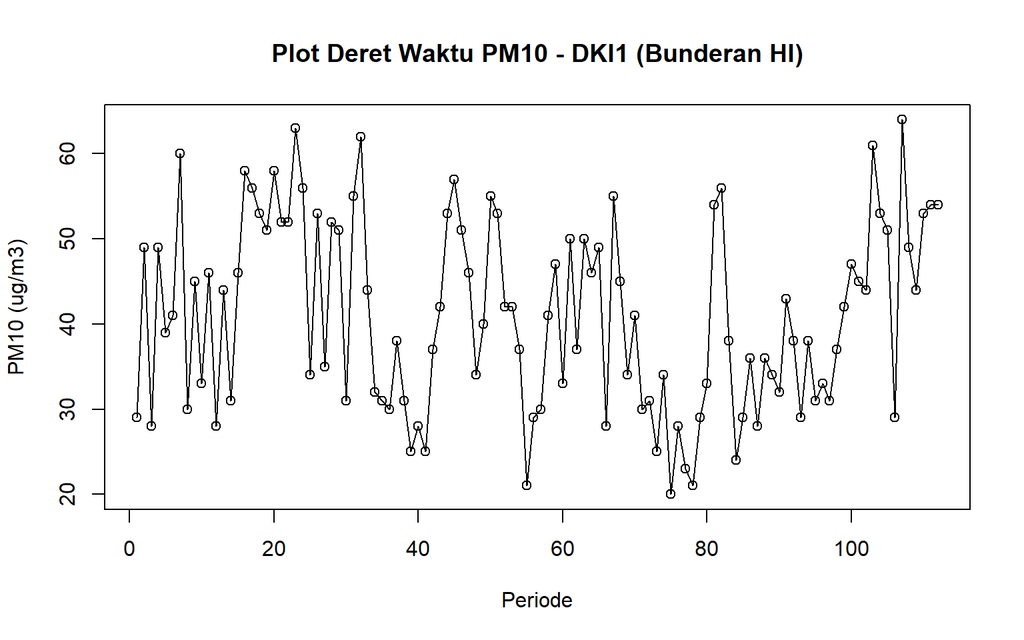

```r
ts.plot(data1.ts, xlab = "Periode", ylab = "PM10 (ug/m3)",
        main = "Plot Deret Waktu PM10 - DKI1 (Bunderan HI)")
points(data1.ts)
```

```r
dev.copy(png, "plot_pm10_full.png"); dev.off()
```

## PEMBAGIAN DATA (80% LATIH, 20% UJI)

Data latih dipakai untuk membentuk model pemulusan, sedangkan data uji disisihkan (tidak “dilihat” model) untuk mengecek seberapa baik model meramalkan data baru. Ini penting karena akurasi yang bagus di data latih saja belum tentu berarti model bagus untuk peramalan sungguhan.

```r
n <- nrow(data1)
n_train <- floor(0.8 * n)

training <- data1[1:n_train, ]
testing  <- data1[(n_train + 1):n, ]

train.ts <- ts(training$pm10)
test.ts  <- ts(testing$pm10)

n_train
```

```
## [1] 89
```

```r
n_test <- nrow(testing)
n_test
```

```
## [1] 23
```

## Eksplorasi data latih & data uji

Sebelum memilih metode pemulusan, lihat dulu pola datanya lewat plot di bawah - apakah datanya cenderung stasioner (naik-turun di sekitar rata-rata yang tetap) atau punya tren jangka panjang. Ini menentukan metode mana yang secara teori paling cocok.

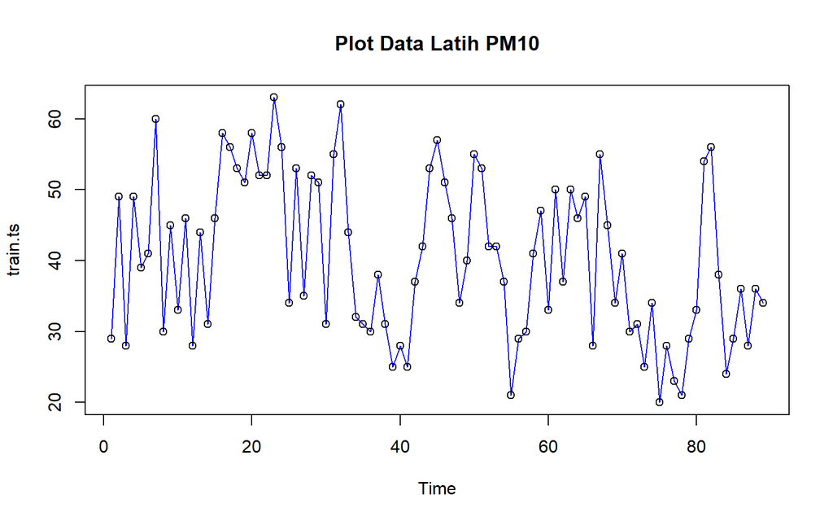

```r
plot(train.ts, col = "blue", main = "Plot Data Latih PM10"); points(train.ts)
```

```r
dev.copy(png, "plot_pm10_train.png"); dev.off()
```

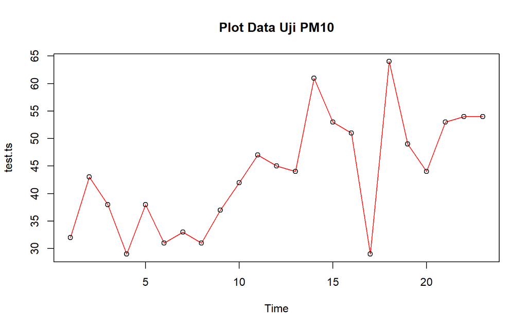

```r
plot(test.ts, col = "red", main = "Plot Data Uji PM10"); points(test.ts)
```

```r
dev.copy(png, "plot_pm10_test.png"); dev.off()
```

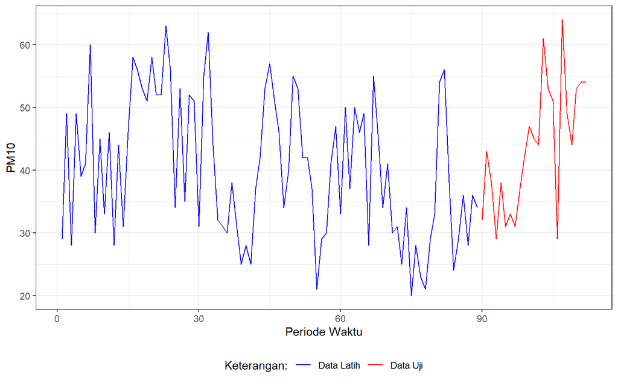

```r
library(ggplot2)
ggplot() +
  geom_line(data = training, aes(x = periode, y = pm10, col = "Data Latih")) +
  geom_line(data = testing,  aes(x = periode, y = pm10, col = "Data Uji")) +
  labs(x = "Periode Waktu", y = "PM10", color = "Legend") +
  scale_colour_manual(name = "Keterangan:", breaks = c("Data Latih", "Data Uji"),
                       values = c("blue", "red")) +
  theme_bw() + theme(legend.position = "bottom")
```

```r
ggsave("plot_pm10_ggplot.png", width = 7, height = 4)
```

# Metode Pemulusan

## SINGLE MOVING AVERAGE (SMA)

SMA cocok untuk data yang polanya relatif stasioner/konstan. Nilai pemulusan periode ke-t dihitung dari rata-rata m data sebelumnya (di sini m = 4), lalu nilai itu dipakai sebagai ramalan periode berikutnya.

```r
m <- 4
data.sma <- SMA(train.ts, n = m)

data.ramal <- c(NA, data.sma)
h_test <- n_test
data.gab <- cbind(
  aktual    = c(data1.ts),
  pemulusan = c(data.sma, rep(NA, h_test)),
  ramalan   = c(data.ramal, rep(data.ramal[length(data.ramal)], h_test - 1))
)
tail(data.gab, h_test + 2)
```

```
##        aktual pemulusan ramalan
##  [88,]     36     32.25   29.25
##  [89,]     34     33.50   32.25
##  [90,]     32        NA   33.50
##  [91,]     43        NA   33.50
##  [92,]     38        NA   33.50
##  [93,]     29        NA   33.50
##  [94,]     38        NA   33.50
##  [95,]     31        NA   33.50
##  [96,]     33        NA   33.50
##  [97,]     31        NA   33.50
##  [98,]     37        NA   33.50
##  [99,]     42        NA   33.50
## [100,]     47        NA   33.50
## [101,]     45        NA   33.50
## [102,]     44        NA   33.50
## [103,]     61        NA   33.50
## [104,]     53        NA   33.50
## [105,]     51        NA   33.50
## [106,]     29        NA   33.50
## [107,]     64        NA   33.50
## [108,]     49        NA   33.50
## [109,]     44        NA   33.50
## [110,]     53        NA   33.50
## [111,]     54        NA   33.50
## [112,]     54        NA   33.50
```

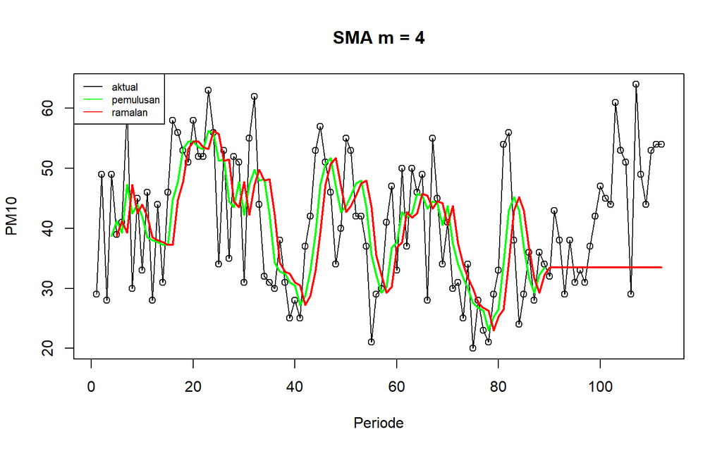

```r
ts.plot(data1.ts, xlab = "Periode", ylab = "PM10", main = paste("SMA m =", m))
points(data1.ts)
lines(data.gab[, 2], col = "green", lwd = 2)
lines(data.gab[, 3], col = "red", lwd = 2)
legend("topleft", c("aktual", "pemulusan", "ramalan"), lty = 1,
       col = c("black", "green", "red"), cex = 0.7)
```

```r
dev.copy(png, "plot_sma.png"); dev.off()
```

## Akurasi data latih

SSE/MSE mengukur besarnya galat kuadrat (makin kecil makin baik, tapi skalanya tergantung satuan data), sedangkan MAPE mengukur galat dalam persen sehingga lebih mudah diinterpretasi lintas metode.

```r
error_train.sma <- train.ts - data.ramal[1:length(train.ts)]
SSE_train.sma  <- sum(error_train.sma[(m+1):length(train.ts)]^2)
MSE_train.sma  <- mean(error_train.sma[(m+1):length(train.ts)]^2)
RMSE_train.sma <- sqrt(MSE_train.sma)
MAPE_train.sma <- mean(abs(error_train.sma[(m+1):length(train.ts)] /
                             train.ts[(m+1):length(train.ts)]) * 100)

akurasi_train.sma <- matrix(c(SSE_train.sma, MSE_train.sma, RMSE_train.sma, MAPE_train.sma))
row.names(akurasi_train.sma) <- c("SSE", "MSE", "RMSE", "MAPE")
colnames(akurasi_train.sma) <- paste("SMA m =", m)
akurasi_train.sma
```

```
##        SMA m = 4
## SSE  10332.43750
## MSE    121.55809
## RMSE    11.02534
## MAPE    24.06691
```

## Akurasi data uji

```r
idx_test <- (length(train.ts) + 1):n
error_test.sma <- test.ts - data.gab[idx_test, 3]
SSE_test.sma  <- sum(error_test.sma^2)
MSE_test.sma  <- mean(error_test.sma^2)
RMSE_test.sma <- sqrt(MSE_test.sma)
MAPE_test.sma <- mean(abs(error_test.sma / test.ts) * 100)

akurasi_test.sma <- matrix(c(SSE_test.sma, MSE_test.sma, RMSE_test.sma, MAPE_test.sma))
row.names(akurasi_test.sma) <- c("SSE", "MSE", "RMSE", "MAPE")
colnames(akurasi_test.sma) <- paste("SMA m =", m)
akurasi_test.sma
```

```
##       SMA m = 4
## SSE  4639.75000
## MSE   201.72826
## RMSE   14.20311
## MAPE   23.43664
```

## DOUBLE MOVING AVERAGE (DMA)

Berbeda dari SMA, DMA lebih cocok untuk data yang punya tren karena pemulusan dilakukan dua kali: hasil SMA pertama dihaluskan sekali lagi, lalu dipakai untuk menghitung komponen level (At) dan tren (Bt). Ramalan ke depan mengikuti garis tren ini, bukan konstan seperti SMA.

```r
dma <- SMA(data.sma, n = m)
At  <- 2 * data.sma - dma
Bt  <- 2 / (m - 1) * (data.sma - dma)
data.dma   <- At + Bt
data.ramal2 <- c(NA, data.dma)

t <- 1:h_test
f <- c()
for (i in t) {
  f[i] <- At[length(At)] + Bt[length(Bt)] * i
}

data.gab2 <- cbind(
  aktual     = c(data1.ts),
  pemulusan1 = c(data.sma, rep(NA, h_test)),
  pemulusan2 = c(dma, rep(NA, h_test)),
  At         = c(At, rep(NA, h_test)),
  Bt         = c(Bt, rep(NA, h_test)),
  ramalan    = c(data.ramal2, f[-1])
)
tail(data.gab2, h_test + 2)
```

```
##        aktual pemulusan1 pemulusan2      At         Bt  ramalan
##  [88,]     36      32.25    32.5000 32.0000 -0.1666667 19.35417
##  [89,]     34      33.50    31.6875 35.3125  1.2083333 31.83333
##  [90,]     32         NA         NA      NA         NA 36.52083
##  [91,]     43         NA         NA      NA         NA 37.72917
##  [92,]     38         NA         NA      NA         NA 38.93750
##  [93,]     29         NA         NA      NA         NA 40.14583
##  [94,]     38         NA         NA      NA         NA 41.35417
##  [95,]     31         NA         NA      NA         NA 42.56250
##  [96,]     33         NA         NA      NA         NA 43.77083
##  [97,]     31         NA         NA      NA         NA 44.97917
##  [98,]     37         NA         NA      NA         NA 46.18750
##  [99,]     42         NA         NA      NA         NA 47.39583
## [100,]     47         NA         NA      NA         NA 48.60417
## [101,]     45         NA         NA      NA         NA 49.81250
## [102,]     44         NA         NA      NA         NA 51.02083
## [103,]     61         NA         NA      NA         NA 52.22917
## [104,]     53         NA         NA      NA         NA 53.43750
## [105,]     51         NA         NA      NA         NA 54.64583
## [106,]     29         NA         NA      NA         NA 55.85417
## [107,]     64         NA         NA      NA         NA 57.06250
## [108,]     49         NA         NA      NA         NA 58.27083
## [109,]     44         NA         NA      NA         NA 59.47917
## [110,]     53         NA         NA      NA         NA 60.68750
## [111,]     54         NA         NA      NA         NA 61.89583
## [112,]     54         NA         NA      NA         NA 63.10417
```

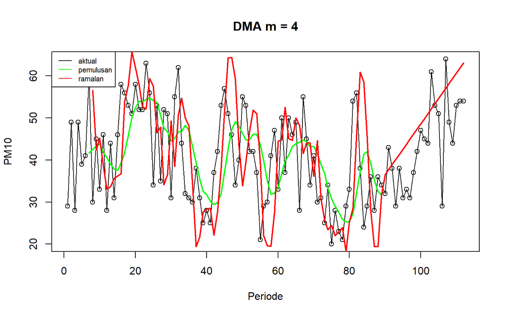

```r
ts.plot(data1.ts, xlab = "Periode", ylab = "PM10", main = paste("DMA m =", m))
points(data1.ts)
lines(data.gab2[, 3], col = "green", lwd = 2)
lines(data.gab2[, 6], col = "red", lwd = 2)
legend("topleft", c("aktual", "pemulusan", "ramalan"), lty = 1,
       col = c("black", "green", "red"), cex = 0.7)
```

```r
dev.copy(png, "plot_dma.png"); dev.off()
```

## Akurasi data latih

```r
start_dma <- 2 * m
error_train.dma <- train.ts - data.ramal2[1:length(train.ts)]
SSE_train.dma  <- sum(error_train.dma[start_dma:length(train.ts)]^2)
MSE_train.dma  <- mean(error_train.dma[start_dma:length(train.ts)]^2)
RMSE_train.dma <- sqrt(MSE_train.dma)
MAPE_train.dma <- mean(abs(error_train.dma[start_dma:length(train.ts)] /
                             train.ts[start_dma:length(train.ts)]) * 100)

akurasi_train.dma <- matrix(c(SSE_train.dma, MSE_train.dma, RMSE_train.dma, MAPE_train.dma))
row.names(akurasi_train.dma) <- c("SSE", "MSE", "RMSE", "MAPE")
colnames(akurasi_train.dma) <- paste("DMA m =", m)
akurasi_train.dma
```

```
##        DMA m = 4
## SSE  14261.80208
## MSE    173.92442
## RMSE    13.18804
## MAPE    29.29730
```

## Akurasi data uji

```r
error_test.dma <- test.ts - data.gab2[idx_test, 6]
SSE_test.dma  <- sum(error_test.dma^2)
MSE_test.dma  <- mean(error_test.dma^2)
RMSE_test.dma <- sqrt(MSE_test.dma)
MAPE_test.dma <- mean(abs(error_test.dma / test.ts) * 100)

akurasi_test.dma <- matrix(c(SSE_test.dma, MSE_test.dma, RMSE_test.dma, MAPE_test.dma))
row.names(akurasi_test.dma) <- c("SSE", "MSE", "RMSE", "MAPE")
colnames(akurasi_test.dma) <- paste("DMA m =", m)
akurasi_test.dma
```

```
##       DMA m = 4
## SSE  2207.81554
## MSE    95.99198
## RMSE    9.79755
## MAPE   21.07678
```

## SINGLE EXPONENTIAL SMOOTHING (SES)

SES memberi bobot yang menurun secara eksponensial pada data lama - data terbaru punya pengaruh lebih besar terhadap ramalan. Cocok untuk data stasioner, mirip SMA, tapi lebih adaptif terhadap perubahan terbaru. Parameter alpha dicari otomatis (nilai optimum) dengan alpha = NULL.

```r
ses.opt <- HoltWinters(train.ts, gamma = FALSE, beta = FALSE, alpha = NULL)
ses.opt
```

```
## Holt-Winters exponential smoothing without trend and without seasonal component.
##
## Call:
## HoltWinters(x = train.ts, alpha = NULL, beta = FALSE, gamma = FALSE)
##
## Smoothing parameters:
##  alpha: 0.3954389
##  beta : FALSE
##  gamma: FALSE
##
## Coefficients:
##       [,1]
## a 33.62027
```

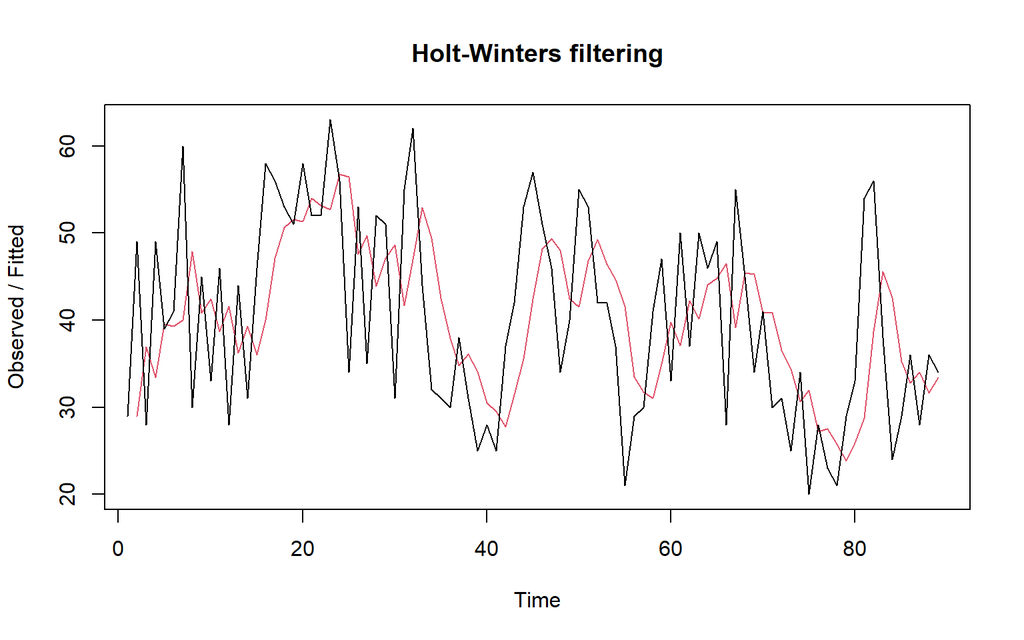

```r
plot(ses.opt); dev.copy(png, "plot_ses.png"); dev.off()
```

```r
ramalan.ses <- forecast(ses.opt, h = n_test)
ramalan.ses
```

```
##     Point Forecast     Lo 80    Hi 80       Lo 95    Hi 95
##  90       33.62027 19.971503 47.26904  12.7462818 54.49426
##  91       33.62027 18.943104 48.29744  11.1734818 56.06706
##  92       33.62027 17.982190 49.25835   9.7038904 57.53665
##  93       33.62027 17.076996 50.16354   8.3195165 58.92102
##  94       33.62027 16.218826 51.02171   7.0070582 60.23348
##  95       33.62027 15.401033 51.83951   5.7563514 61.48419
##  96       33.62027 14.618403 52.62214   4.5594223 62.68112
##  97       33.62027 13.866756 53.37378   3.4098780 63.83066
##  98       33.62027 13.142681 54.09786   2.3025003 64.93804
##  99       33.62027 12.443349 54.79719   1.2329636 66.00758
## 100       33.62027 11.766384 55.47416   0.1976350 67.04290
## 101       33.62027 11.109768 56.13077  -0.8065719 68.04711
## 102       33.62027 10.471770 56.76877  -1.7823056 69.02284
## 103       33.62027  9.850890 57.38965  -2.7318588 69.97240
## 104       33.62027  9.245821 57.99472  -3.6572324 70.89777
## 105       33.62027  8.655413 58.58513  -4.5601844 71.80072
## 106       33.62027  8.078648 59.16189  -5.4422698 72.68281
## 107       33.62027  7.514623 59.72592  -6.3048715 73.54541
## 108       33.62027  6.962529 60.27801  -7.1492264 74.38977
## 109       33.62027  6.421639 60.81890  -7.9764457 75.21698
## 110       33.62027  5.891299 61.34924  -8.7875320 76.02807
## 111       33.62027  5.370912 61.86963  -9.5833940 76.82393
## 112       33.62027  4.859940 62.38060 -10.3648581 77.60540
```

## Akurasi data latih

```r
SSE.ses  <- ses.opt$SSE
MSE.ses  <- SSE.ses / length(train.ts)
RMSE.ses <- sqrt(MSE.ses)
sisaan.ses <- ramalan.ses$residuals
MAPE.ses <- mean(abs(sisaan.ses[2:length(train.ts)] /
                       train.ts[2:length(train.ts)]) * 100)

akurasi_train.ses <- matrix(c(SSE.ses, MSE.ses, RMSE.ses, MAPE.ses))
row.names(akurasi_train.ses) <- c("SSE", "MSE", "RMSE", "MAPE")
colnames(akurasi_train.ses) <- paste("SES alpha =", round(ses.opt$alpha, 3))
akurasi_train.ses
```

```
##      SES alpha = 0.395
## SSE         9869.65997
## MSE          110.89506
## RMSE          10.53067
## MAPE          23.45307
```

## Akurasi data uji

```r
e.ses <- as.numeric(ramalan.ses$mean) - as.numeric(testing$pm10)
SSE_test.ses  <- sum(e.ses^2)
MSE_test.ses  <- mean(e.ses^2)
RMSE_test.ses <- sqrt(MSE_test.ses)
MAPE_test.ses <- mean(abs(e.ses / testing$pm10) * 100)

akurasi_test.ses <- matrix(c(SSE_test.ses, MSE_test.ses, RMSE_test.ses, MAPE_test.ses))
row.names(akurasi_test.ses) <- c("SSE", "MSE", "RMSE", "MAPE")
colnames(akurasi_test.ses) <- paste("SES alpha =", round(ses.opt$alpha, 3))
akurasi_test.ses
```

```
##      SES alpha = 0.395
## SSE         4584.39785
## MSE          199.32165
## RMSE          14.11813
## MAPE          23.34907
```

## DOUBLE EXPONENTIAL SMOOTHING (DES)

DES adalah versi SES yang diperluas untuk menangkap tren: proses pemulusan dilakukan dua kali, sekali untuk level dan sekali untuk tren, sehingga hasil ramalannya tidak konstan melainkan mengikuti arah naik/turun data. Parameter alpha dan beta dicari otomatis nilai optimumnya.

```r
des.opt <- HoltWinters(train.ts, gamma = FALSE)
des.opt
```

```
## Holt-Winters exponential smoothing with trend and without seasonal component.
##
## Call:
## HoltWinters(x = train.ts, gamma = FALSE)
##
## Smoothing parameters:
##  alpha: 0.6409322
##  beta : 0.2567313
##  gamma: FALSE
##
## Coefficients:
##          [,1]
## a 33.65587456
## b  0.03735992
```

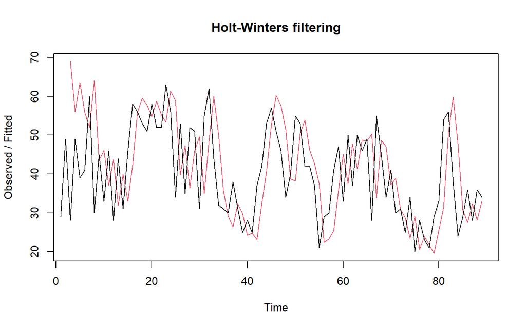

```r
plot(des.opt); dev.copy(png, "plot_des.png"); dev.off()
```

```r
ramalan.des <- forecast(des.opt, h = n_test)
ramalan.des
```

```
##     Point Forecast       Lo 80     Hi 80       Lo 95     Hi 95
##  90       33.69323   17.337458  50.04901    8.679233  58.70724
##  91       33.73059   12.728878  54.73231    1.611241  65.84995
##  92       33.76795    7.447097  60.08881   -6.486323  74.02223
##  93       33.80531    1.600596  66.01003  -15.447552  83.05818
##  94       33.84267   -4.740060  72.42541  -25.164526  92.84987
##  95       33.88003  -11.526179  79.28625  -35.562777 103.32284
##  96       33.91739  -18.722140  86.55693  -46.587826 114.42261
##  97       33.95475  -26.300558  94.21007  -58.197793 126.10730
##  98       33.99211  -34.239525 102.22375  -70.359172 138.34340
##  99       34.02947  -42.520957 110.57990  -83.044308 151.10326
## 100       34.06683  -51.129555 119.26322  -96.229800 164.36347
## 101       34.10419  -60.052120 128.26051 -109.895462 178.10385
## 102       34.14155  -69.277085 137.56019 -124.023605 192.30671
## 103       34.17891  -78.794184 147.15201 -138.598530 206.95636
## 104       34.21627  -88.594215 157.02676 -153.606160 222.03871
## 105       34.25363  -98.668849 167.17612 -169.033761 237.54103
## 106       34.29099 -109.010500 177.59249 -184.869728 253.45171
## 107       34.32835 -119.612211 188.26892 -201.103423 269.76013
## 108       34.36571 -130.467567 199.19899 -217.725035 286.45646
## 109       34.40307 -141.570627 210.37677 -234.725477 303.53162
## 110       34.44043 -152.915865 221.79673 -252.096298 320.97716
## 111       34.47779 -164.498120 233.45371 -269.829605 338.78519
## 112       34.51515 -176.312558 245.34286 -287.918007 356.94831
```

## Akurasi data latih

```r
SSE.des  <- des.opt$SSE
MSE.des  <- SSE.des / length(train.ts)
RMSE.des <- sqrt(MSE.des)
sisaan.des <- ramalan.des$residuals
MAPE.des <- mean(abs(sisaan.des[3:length(train.ts)] /
                       train.ts[3:length(train.ts)]) * 100)

akurasi_train.des <- matrix(c(SSE.des, MSE.des, RMSE.des, MAPE.des))
row.names(akurasi_train.des) <- c("SSE", "MSE", "RMSE", "MAPE")
colnames(akurasi_train.des) <- paste0("DES alpha=", round(des.opt$alpha,3),
                                       " beta=", round(des.opt$beta,3))
akurasi_train.des
```

```
##      DES alpha=0.641 beta=0.257
## SSE                 14176.93150
## MSE                   159.29137
## RMSE                   12.62107
## MAPE                   27.61740
```

## Akurasi data uji

```r
e.des <- as.numeric(ramalan.des$mean) - as.numeric(testing$pm10)
SSE_test.des  <- sum(e.des^2)
MSE_test.des  <- mean(e.des^2)
RMSE_test.des <- sqrt(MSE_test.des)
MAPE_test.des <- mean(abs(e.des / testing$pm10) * 100)

akurasi_test.des <- matrix(c(SSE_test.des, MSE_test.des, RMSE_test.des, MAPE_test.des))
row.names(akurasi_test.des) <- c("SSE", "MSE", "RMSE", "MAPE")
colnames(akurasi_test.des) <- paste0("DES alpha=", round(des.opt$alpha,3),
                                      " beta=", round(des.opt$beta,3))
akurasi_test.des
```

```
##      DES alpha=0.641 beta=0.257
## SSE                  4293.22919
## MSE                   186.66214
## RMSE                   13.66244
## MAPE                   22.78797
```

# Kesimpulan

## PERBANDINGAN KESELURUHAN METODE

Tabel berikut merangkum SSE, MSE, RMSE, dan MAPE dari keempat metode, baik pada data latih maupun data uji. Fokus utama penilaian ada pada MAPE data uji, karena ini menggambarkan performa model pada data yang benar-benar belum pernah dipakai untuk membentuk model.

```r
tabel_akurasi <- data.frame(
  Metode = c("SMA", "DMA", "SES", "DES"),
  SSE_Latih  = c(SSE_train.sma, SSE_train.dma, SSE.ses, SSE.des),
  MSE_Latih  = c(MSE_train.sma, MSE_train.dma, MSE.ses, MSE.des),
  RMSE_Latih = c(RMSE_train.sma, RMSE_train.dma, RMSE.ses, RMSE.des),
  MAPE_Latih = c(MAPE_train.sma, MAPE_train.dma, MAPE.ses, MAPE.des),
  SSE_Uji  = c(SSE_test.sma, SSE_test.dma, SSE_test.ses, SSE_test.des),
  MSE_Uji  = c(MSE_test.sma, MSE_test.dma, MSE_test.ses, MSE_test.des),
  RMSE_Uji = c(RMSE_test.sma, RMSE_test.dma, RMSE_test.ses, RMSE_test.des),
  MAPE_Uji = c(MAPE_test.sma, MAPE_test.dma, MAPE_test.ses, MAPE_test.des)
)
print(tabel_akurasi, digits = 4)
```

```
##   Metode SSE_Latih MSE_Latih RMSE_Latih MAPE_Latih SSE_Uji MSE_Uji RMSE_Uji
## 1    SMA     10332     121.6      11.03      24.07    4640  201.73   14.203
## 2    DMA     14262     173.9      13.19      29.30    2208   95.99    9.798
## 3    SES      9870     110.9      10.53      23.45    4584  199.32   14.118
## 4    DES     14177     159.3      12.62      27.62    4293  186.66   13.662
##   MAPE_Uji
## 1    23.44
## 2    21.08
## 3    23.35
## 4    22.79
```

Berdasarkan nilai MAPE data uji, metode terbaik untuk meramalkan PM10 pada stasiun DKI1 (Bunderan HI) adalah DMA dengan MAPE sebesar 21.08%.

Metode DMA unggul karena mampu menangkap pola tren naik-turun jangka pendek pada data PM10 secara lebih adaptif dibandingkan metode lain, sehingga menghasilkan galat peramalan yang lebih kecil ketika diuji pada data yang belum pernah “dilihat” model. Seluruh metode menghasilkan MAPE pada kisaran 20-30%, yang menurut kriteria Lewis (1982) tergolong “cukup baik” (reasonable forecasting) - wajar mengingat data kualitas udara harian bersifat fluktuatif secara alami.